# Reproductible Research - Week 2 - Assignement 1

## Are there differences in activity patterns between weekdays and weekends?

For this part the weekdays() function may be of some help here. Use the dataset with the filled-in missing values for this part.

1. Create a new factor variable in the dataset with two levels - “weekday” and “weekend” indicating whether a given date is a weekday or weekend day.

```r
Sys.setlocale("LC_TIME", locale="USA")
```

```
## [1] "English_United States.1252"
```

```r
# Weekdays calculation
TypeOfDay <- weekdays(as.Date(db_all$date))
# Assign the weekdays and the weekends to the data set
TypeOfDay2 <- ifelse(test = TypeOfDay %in% c("Saturday", "Sunday"), yes="weekend", "weekday")
db_all$TypeOfDay <- as.factor(TypeOfDay2)
```

The new vector variable named “TypeOfDay” has been added to the new database “db_all”

2. Make a panel plot containing a time series plot (i.e. type = “l”) of the 5-minute interval (x-axis) and the average number of steps taken, averaged across all weekday days or weekend days (y-axis). See the README file in the GitHub repository to see an example of what this plot should look like using simulated data.

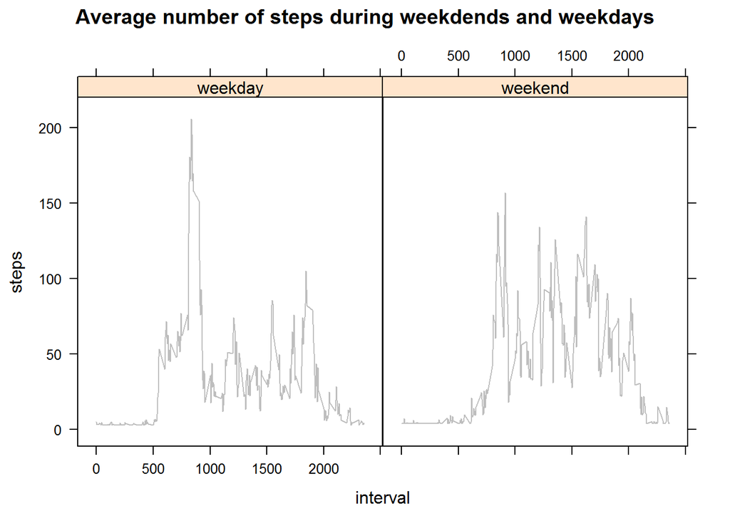